# Premiers pas avec shiny… et les packages de visualisation interactive

B.Thieurmel, benoit.thieurmel@datastorm.fr

04/07/2018

# Shiny : créer des applications web avec le logiciel R

**Shiny** est un package **R** qui permet la création simple d’applications web intéractives depuis le logiciel open-source **R**.

- pas de connaissances *web* nécessaires
- le pouvoir de calcul de R et l’intéractivité du web actuel
- pour créer des applications locales
- ou partagées avec l’utilisation de **shiny-server**, **shinyapps.io**, **shinyproxy**

http://shiny.rstudio.com

http://www.shinyapps.io/

https://www.shinyproxy.io/

https://www.rstudio.com/products/shiny/shiny-server/

Une application **shiny** nécessite un ordinateur/un serveur éxécutant **R**

[figure not shown]

server

# Ma première application avec shiny

- Initialiser une application est simple avec **RStudio**, en créant un nouveau projet
- File > New Project > New Directory > Shiny Web Application
- Basée sur deux scripts : ui.R et server.R
- Et utilisant par défaut le sidebar layout
- Commandes utiles :
- lancement de l’application : bouton **Run app**
- actualisatisation : bouton **Reload app**
- arrêt : bouton **Stop**

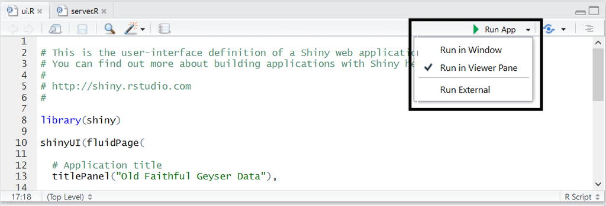

run

- **Run in Window** : Nouvelle fenêtre, utilisant l’environnement **RStudio**
- **Run in Viewer Pane** : Dans l’onglet *Viewer* de **RStudio**
- **Run External** : Dans le navigateur web par défaut

[figure not shown]

stop

# Structure d’une application

## Un dossier avec un seul fichier

**conventions :**

- enregistré sous le nom **app.R**
- se terminant par la commande shinyApp()
- pour les **applications légères**

[figure not shown]

Understand communication

```r
library(shiny)
ui <- fluidPage(
  sliderInput(inputId = "num", label = "Choose a number",
              value = 25, min = 1, max = 100),
  plotOutput("hist")
)
server <- function(input, output) {
  output$hist <- renderPlot({
    hist(rnorm(input$num))
  })
}
shinyApp(ui = ui, server = server)
```

## Un dossier avec deux fichiers

**conventions :**

- côté interface utilisateur dans le script **ui.R**
- côté serveur dans le script **server.R**
- structure à **priviliégier**

[figure not shown]

Understand communication

**ui.R**

```r
library(shiny)
fluidPage(
  sliderInput(inputId = "num", label = "Choose a number",
              value = 25, min = 1, max = 100),
  plotOutput("hist")
)
```

**server.R**

```r
library(shiny)
function(input, output) {
  output$hist <- renderPlot({hist(rnorm(input$num))})
}
```

## Données/fichiers complémentaires

- le code **R** tourne au niveau des scripts **R**, et peut donc accéder de façon relative à tous les objets présents dans le dossier de l’application
- l’application web, comme de convention, accède à tous les éléments présents dans le dossier `www` (css, images, javascript, documentation, …)

[figure not shown]

Understand communication

## Partage ui <-> server

**Le server et l’ui communiquent uniquement par le biais des inputs et des outputs**

- Nous pouvons ajouter un script nommé **global.R** pour partager des éléments (variables, packages, …) entre la partie **UI** et la partie **SERVER**
- Tout ce qui est présent dans le **global.R** est visible à la fois dans le **ui.R** et dans le **server.R**
- Le script **global.R** est chargé uniquement une seul fois au lancement de l’application
- Dans le cas d’une utilisation avec un `shiny-server`, les objets globaux sont également partagés entre les utilisateurs

# Intéractivité et communication

## Introduction

**ui.R**:

```r
library(shiny)

# Define UI for application that draws a histogram
shinyUI(fluidPage(
  # Application title
  titlePanel("Hello Shiny!"),
  # Sidebar with a slider input for the number of bins
  sidebarLayout(
    sidebarPanel(
      sliderInput(inputId = "bins",
                  label = "Number of bins:",
                  min = 1, max = 50, value = 30)
    ),
    # Show a plot of the generated distribution
    mainPanel(plotOutput(outputId = "distPlot"))
  )
))
```

**server.R**:

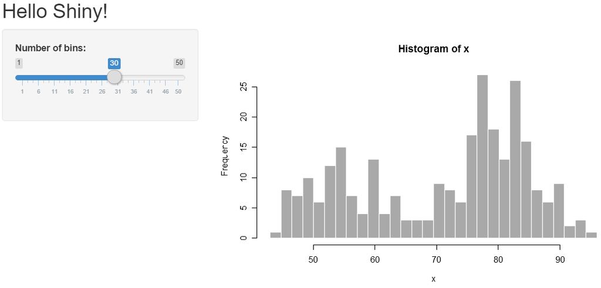

hello

```r
library(shiny)

# Define server logic required to draw a histogram
shinyServer(function(input, output) {
  # Expression that generates a histogram. The expression is
  # wrapped in a call to renderPlot to indicate that:
  #
  #  1) It is "reactive" and therefore should be automatically
  #     re-executed when inputs change
  #  2) Its output type is a plot
  output$distPlot <- renderPlot({
    x    <- faithful[, 2]  # Old Faithful Geyser data
    bins <- seq(min(x), max(x), length.out = input$bins + 1)
    # draw the histogram with the specified number of bins
    hist(x, breaks = bins, col = 'darkgray', border = 'white')
  })
})
```

Avec cette exemple simple, nous comprenons :

- Côté **ui**, nous définissons un slider numérique avec le code “`sliderInput(inputId = "bins",...)`” et on utilise sa valeur côté **server** avec la notation “`input$bins`” : c’est comme cela que le **ui** créé des variables disponibles dans le **server** !
- Côété **server**, nous créons un graphique “`output$distPlot <- renderPlot({...})`” et l’appelons dans le **ui** avec “`plotOutput(outputId = "distPlot")`”, c’est comme cela que le **server** retourne des objet à **ui** !

## Process

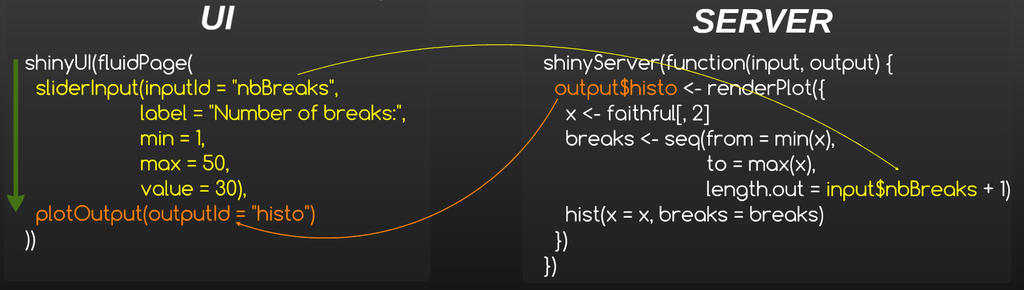

Understand communication

**Le server et l’ui communiquent uniquement par le biais des inputs et des outputs**

**Par défaut, un output est mis-à-jour chaque fois qu’un input en lien change**

## Notice

**la définition de l’interface utilisateur : UI**

- la déclaration des inputs
- la structure de la page, avec le placement des outputs

**la partie serveur/calculs : SERVER**

- la déclaration et le calcul des outputs

## UI

**Deux types d’éléments dans le UI**

- xxInput(inputId = …, …):
- définit un élément qui permet une action de l’utilisateur
- accessible côté serveur avec son identifiant **input$inputID**

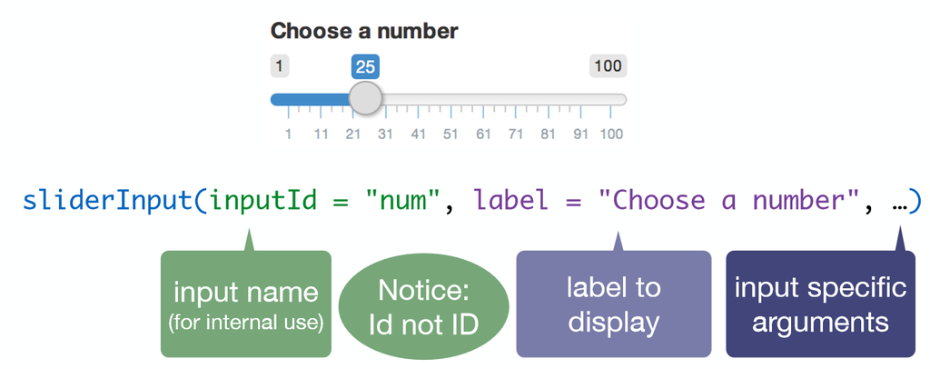

Understand communication

- xxOutput(ouputId = …):
- fait référence à un output créé et défini côté serveur
- en général : graphiques et tableaux

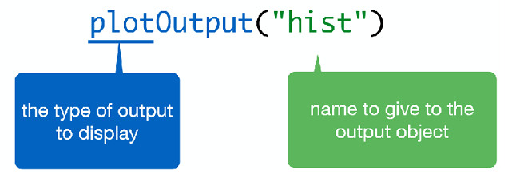

Understand communication

## Serveur

**Définition des outputs dans le serveur**

- renderXX({expr}):
- calcule et retourne une sortie, dépendante d’inputs, via une expression **R**

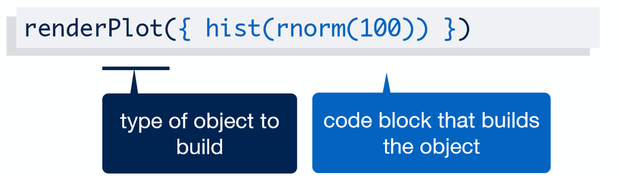

Understand communication

## Retour sur le process

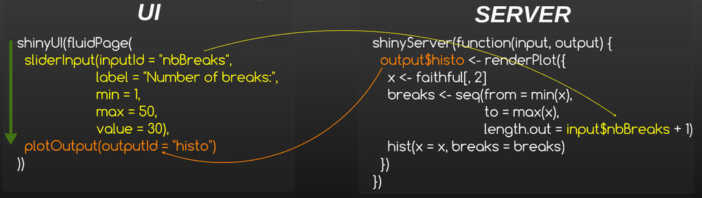

Understand communication

**C’est plus clair ?**

# Les inputs

## Vue globale

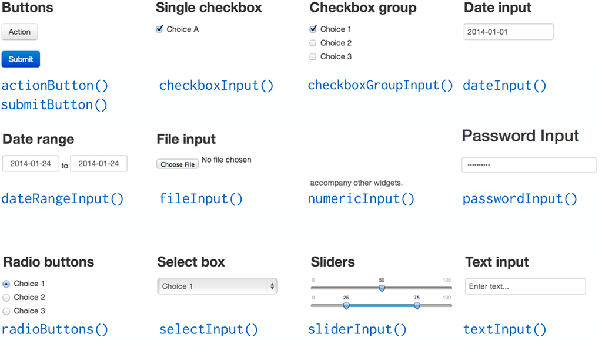

Understand communication

## Valeur numérique

- La fonction

```r
numericInput(inputId, label, value, min = NA, max = NA, step = NA)
```

- Exemple:

```r
numericInput(inputId = "idNumeric", label = "Please select a number",
             value = 0, min = 0, max = 100, step = 10)

# For the server input$idNumeric will be of class "numeric"
# ("integer" when the parameter step is an integer value)
```

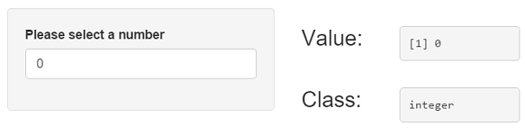

numeric

## Chaîne de caractères

- La fonction

```r
textInput(inputId, label, value = "")
```

- Exemple:

```r
textInput(inputId = "idText", label = "Enter a text", value = "")

# For the server input$idText will be of class "character"
```

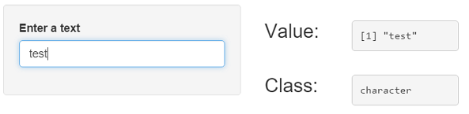

text

## Liste de sélection

- La fonction

```r
selectInput(inputId, label, choices, selected = NULL, multiple = FALSE,
            selectize = TRUE, width = NULL, size = NULL)
```

- Exemple:

```r
selectInput(inputId = "idSelect", label = "Select among the list: ", selected = 3,
            choices = c("First" = 1, "Second" = 2, "Third" = 3))

# For the server input$idSelect is of class "character"
# (vector when the parameter "multiple" is TRUE)
```

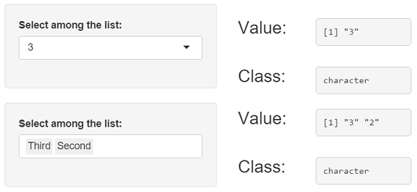

us

## Checkbox

- La fonction

```r
checkboxInput(inputId, label, value = FALSE)
```

- Exemple:

```r
checkboxInput(inputId = "idCheck1", label = "Check ?")

# For the server input$idCheck1 is of class "logical"
```

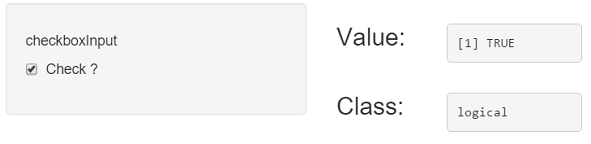

sc

## Checkboxes multiple

- La fonction

```r
checkboxGroupInput(inputId, label, choices, selected = NULL, inline = FALSE)
```

- Exemple:

```r
checkboxGroupInput(inputId = "idCheckGroup", label = "Please select", selected = 3,
                   choices = c("First" = 1, "Second" = 2, "Third" = 3))

# For the server input$idCheckGroup is a "character" vector
```

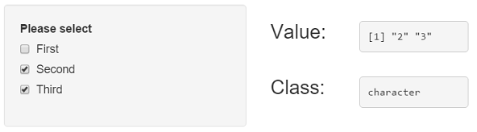

mc

## Radio boutons

- La fonction

```r
radioButtons(inputId, label, choices, selected = NULL, inline = FALSE)
```

- Exemple:

```r
radioButtons(inputId = "idRadio", label = "Select one", selected = 3,
             choices = c("First" = 1, "Second" = 2, "Third" = 3))

# For the server input$idRadio is a "character"
```

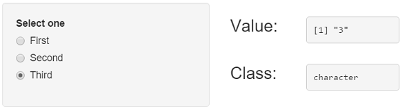

rb

## Date

- La fonction

```r
dateInput(inputId, label, value = NULL, min = NULL, max = NULL, format = "yyyy-mm-dd",
          startview = "month", weekstart = 0, language = "en")
```

- Exemple:

```r
dateInput(inputId = "idDate", label = "Please enter a date", value = "12/08/2015",
          format = "dd/mm/yyyy", startview = "month", weekstart = 0, language = "fr")

# For the server input$idDate is a "Date"
```

[figure not shown]

d

## Période

- La fonction

```r
dateRangeInput(inputId, label, start = NULL, end = NULL, min = NULL, max = NULL,
               format = "yyyy-mm-dd", startview = "month", weekstart = 0,
               language = "en", separator = " to ")
```

- Exemple:

```r
dateRangeInput(inputId = "idDateRange", label = "Please Select a date range",
               start = "2015-01-01", end = "2015-08-12", format = "yyyy-mm-dd",
               language = "en", separator = " to ")

# For the server input$idDateRange is a vector of class "Date" with two elements
```

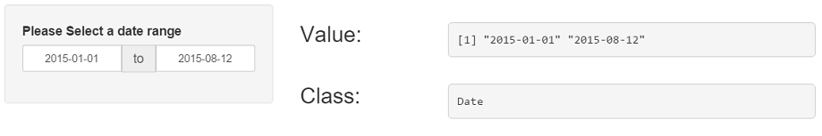

dr

## Slider numérique : valeur unique

- La fonction

```r
sliderInput(inputId, label, min, max, value, step = NULL, round = FALSE,
            format = NULL, locale = NULL, ticks = TRUE, animate = FALSE,
            width = NULL, sep = ",", pre = NULL, post = NULL)
```

- Exemple:

```r
sliderInput(inputId = "idSlider1", label = "Select a number", min = 0, max = 10,
            value = 5, step = 1)

# For the server input$idSlider1 is a "numeric"
# (integer when the parameter "step" is an integer too)
```

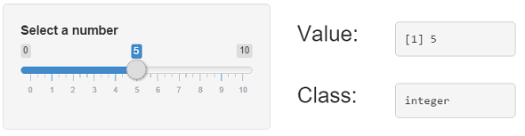

sl

## Slider numérique : range

- La fonction

```r
sliderInput(inputId, label, min, max, value, step = NULL, round = FALSE,
            format = NULL, locale = NULL, ticks = TRUE, animate = FALSE,
            width = NULL, sep = ",", pre = NULL, post = NULL)
```

- Exemple:

```r
sliderInput(inputId = "idSlider2", label = "Select a number", min = 0, max = 10,
            value = c(2,7), step = 1)

# For the server input$idSlider2 is a "numeric" vector
# (integer when the parameter "step" is an integer too)
```

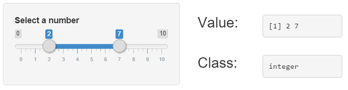

msl

## Importer un fichier

- La fonction

```r
fileInput(inputId, label, multiple = FALSE, accept = NULL)
```

- Exemple:

```r
fileInput(inputId = "idFile", label = "Select a file")

# For the server input$idFile is a "data.frame" with four "character" columns
# (name, size, type and datapath) and one row
```

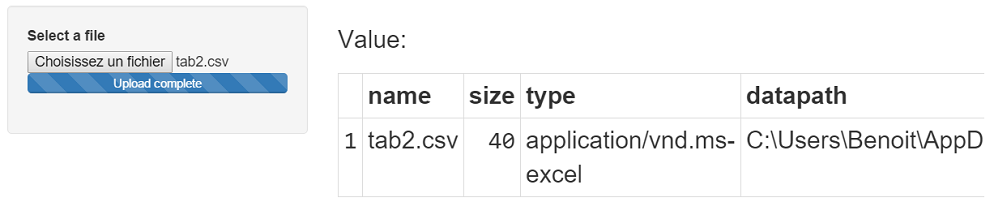

up

## Action Bouton

- La fonction

```r
actionButton(inputId, label, icon = NULL, ...)
```

- Exemple:

```r
actionButton(inputId = "idActionButton", label = "Click !",
             icon = icon("hand-spock-o"))

# For the server input$idActionButton is an "integer"
```

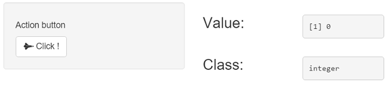

ab

## Aller plus loin : construire son propre input

**Avec un peu de compétences en HTML/CSS/JavaScript, il est également possible de construire des inputs personnalisés**

Un tutoriel est disponible : http://shiny.rstudio.com/articles/building-inputs.html

Ainsi que deux applications d’exemples :

- http://shiny.rstudio.com/gallery/custom-input-control.html
- http://shiny.rstudio.com/gallery/custom-input-bindings.html

# Outputs

## Vue globale

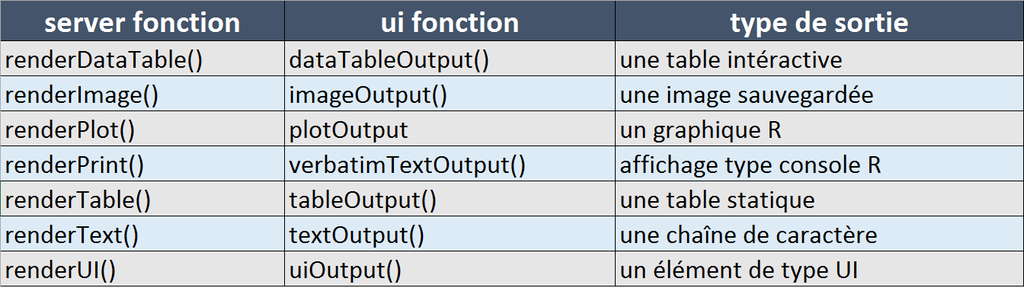

ab

## Les bonnes règles de construction

- assigner l’output à afficher dans la liste **output**, avec un nom permettant l’identification côté **UI**
- utiliser une fonction **renderXX({expr})**
- **la dernière expression doit correspondre au type d’objet retourné**
- accéder aux inputs, et amener la réactivité, en utilisant la liste **input** et l’identifiant : **input$inputId**

```r
#ui.R
selectInput("lettre", "Lettres:", LETTERS[1:3])
verbatimTextOutput(outputId = "selection")
#server.R
output$selection <- renderPrint({input$lettre})
```

## Print

- **ui.r**:

```r
verbatimTextOutput(outputId = "texte")
```

- **server.r**:

```r
output$texte <- renderPrint({
  c("Hello shiny !")
})
```

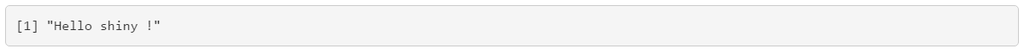

op

## Text

- **ui.r**:

```r
textOutput(outputId = "texte")
```

- **server.r**:

```r
output$texte <- renderText({
  c("Hello shiny !")
})
```

### Plot

- **ui.r**:

```r
plotOutput("myplot")
```

- **server.r**:

[figure not shown]

op3

```r
output$myplot <- renderPlot({
  hist(iris$Sepal.Length)
})
```

## Table

- **ui.r**:

```r
tableOutput(outputId = "table")
```

- **server.r**:

```r
output$table <- renderTable({iris})
```

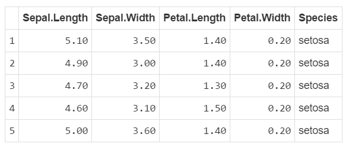

op4

## DataTable

- **ui.r**:

```r
dataTableOutput(outputId = "dataTable")
```

- **server.r**:

```r
output$dataTable <- renderDataTable({
  iris
})
```

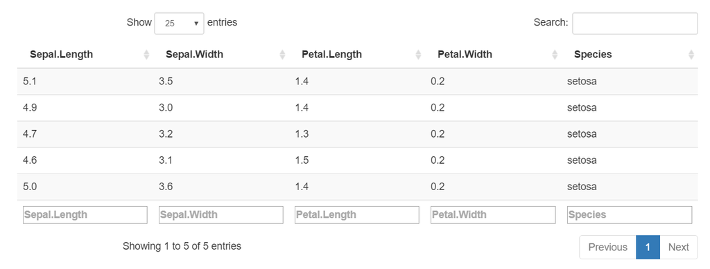

op5

## Définir des élements de l’UI côté SERVER | Définition

**Dans certains cas, nous souhaitons définir des inputs ou des structures côté server**

Cela est possible avec les fonctions `uiOutput` et `renderUI`

## Définir des élements de l’UI côté SERVER | Exemple simple

- **ui.r**:

```r
uiOutput(outputId = "columns")
```

- **server.r**:

```r
output$columns <- renderUI({
  selectInput(inputId = "sel_col", label = "Column", choices = colnames(data))
})
```

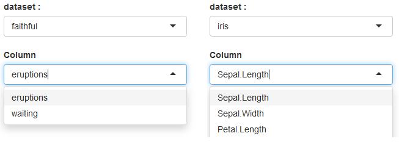

op5

## Définir des élements de l’UI côté SERVER | Exemple plus complexe

- **On peut également renvoyer un élément plus complexe de l’UI, par exemple :**
  - tout en `layout`
  - ou une `fluidRow`
- **ui.r**:

```r
uiOutput(outputId = "fluidRow_ui")
```

- **server.r**:

```r
output$fluidRow_ui <- renderUI(
  fluidRow(
    column(width = 3, h3("Value:")),
    column(width = 3, h3(verbatimTextOutput(outputId = "slinderIn_value")))
  )
)
```

## Aller plus loin : construire son propre output

**Avec un peu de compétences en HTML/CSS/JavaScript, il est également possible de construire des outputs personnalisés**

Un tutoriel est disponible : http://shiny.rstudio.com/articles/building-outputs.html

On peut donc par exemple ajouter comme output un graphique construit avec la librairie [d3.js](https://d3js.org/). Un exemple est disponible dans le dossier `shinyApps/build_output`.